# Paper 2: Survey pre-test

Isabel Chew

8/14/2020

I conducted a pre-test of my survey for paper 2 in April 2020. The results below are meant to provide a demonstration of how the final data would look like, and **not** to serve as any kind of preliminary results due to severe data limitations. This pre-test was conducted using an online platform and was also administered online due to covid restrictions.

Some considerations for future survey execution:

- One potential issue with administering the survey online is the lack of control over respondents’ devices, which have inconsistent encoding of the Burmese language. Although I created two versions of the survey (Zawgyi and unicode), illegible characters still showed up for a few of the respondents. This can be resolved through f2f administration using a specific set of devices.
- I offered a Jinghpaw version of the survey as well. However, despite Jinghpaw being their first language, my RAs had difficulties translating parts of the survey because it is not commonly used in an “academic” setting.Some words were thus unfamiliar to them. If I do offer a Jinghpaw version for the actual data collection, it would be very important to ensure that the Burmese and Jinghpaw translations are congruent and accurate.
- The survey I ran was too long. Some of the question formats were also unfamiliar to the respondents, so more detailed/clearer instructions need to be provided. (Again, if the survey is being administered F2F, it may be less of a problem).
- I plan to further review the translation as some terms, like ethnicity itself, are contentious, without any easy translation in Burmese or Jinghpaw. There were also some mistakes/ambiguities in the first version. For example, the term Burmese was used instead of Bamar. Although in everyday speech, people used Burmese when they are referring to Bamar people, this can be confusing since Burmese is also used to refer to anyone from the country of Burma.

## 1. Sample breakdown

Let’s look at the profile of my pre-test sample, specifically: 1) age 2) gender 3) Education level 4) Religion 5) Ethnicity 6) First language

N=43

From the breakdown, we can see that the sample is not very representative of Kachin state, especially when it comes to age and education. This is not surprising since recruitment was primarily through a convenience sample based on my RAs’ networks (which is younger and more highly educated).

- Ethnicity was asked using a free-text response option. The translation for ethnicity needs to be rechecked. ‘Lumyo’ is more commonly understood as politically defined racial categories whereas ‘myo nweh su’ connotes some kind of ancestral lineage. In this case, the word ‘myo nweh su’ was used, which may explain why answers include Kachin subgroups and Kachin clan names.

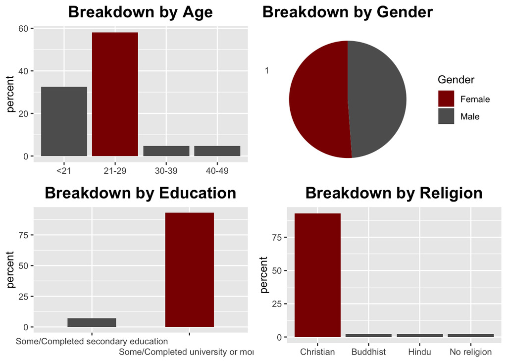

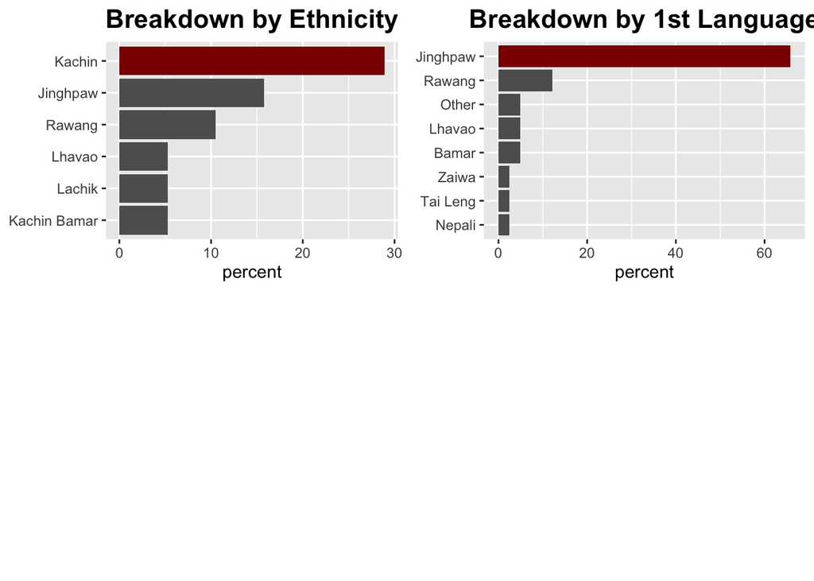

# 2. Survey Responses

## 2.1 Degree of closeness

I asked respondents to indicate the identity categories that they feel closest to.

The question got respondents to rank 6 categories according to their degree of closeness. They did not have to rank all 6 categories, just the ones that applied to them. Additionally, some respondents also placed certain categories at the same rank (which is permissible).

The categories included:

- Their village/ward
- Their linguistic group (defined by the language they indicated to be their first language)
- Ethnic category of Kachin
- Ethnic catgeory of Shan
- Kachin state
- Myanmar

Perhaps as a consequence of the way the question was asked (in terms of closeness/sense of belonging), the category that was ranked #1 the most number of times was village/ward. What is notable, is that #2 is not the ethnic catgeory ‘Kachin’, but rather the respondents’ first language, which usually corresponds to ethnic subgroups (For instance, with the Kachin category, linguistic subgroups include the Rawang, Lisu, Lhavao, Lachik and Jinghpaw). Again, with the caveat that the findings are not representative of my target population, *it would be interesting to see how politically defined ethnic categories may not necessarily align with individuals’ sense of belonging/self, even in places where ethnicity is politically salient.*

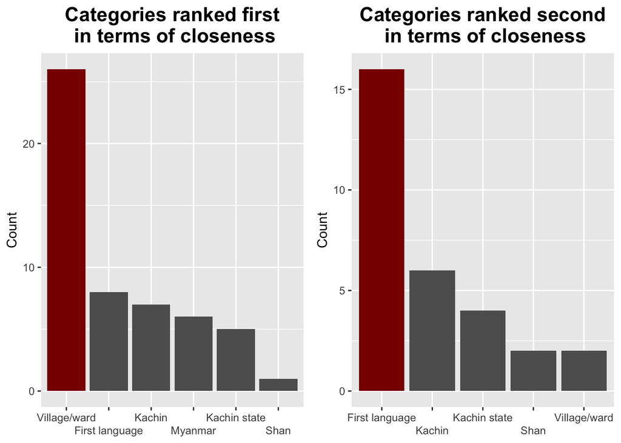

## 2.2 Attitudes towards diversity

I first look at respondents’ contact with people from other groups. In general, everyone in my sample has opportunities in their daily lives to meet people from other ethnic or language groups. Additionally, most people have friends/close friends from other groups.

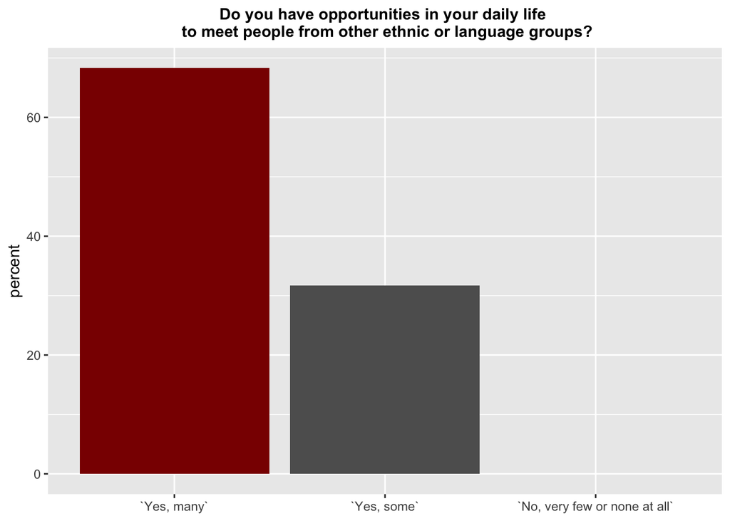

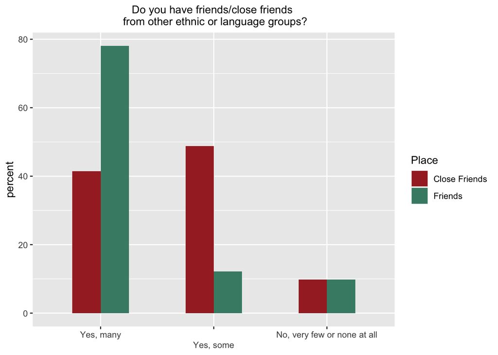

I now look at attitudes towards diversity. In general, respondents were more likely to see people in Kachin state as sharing more similarities than differences as compared to the whole of Myanmar.

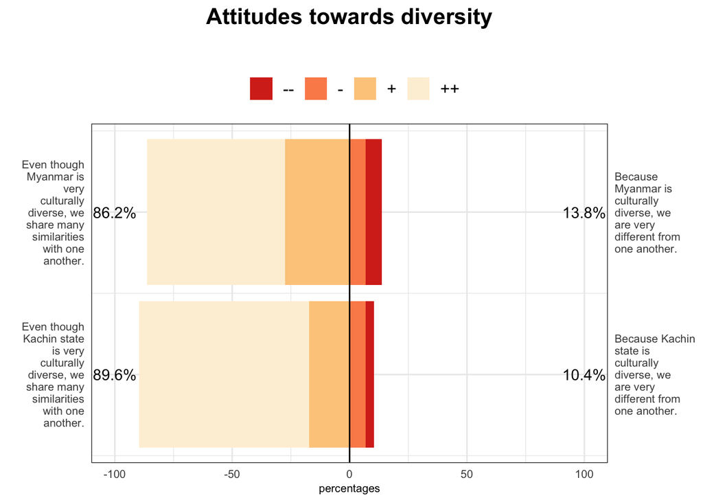

90% of respondents agreed that Myanmar could benefit from having a diversity of ethnic groups compared to 85% of respondents for Kachin state. It would be interesting to see which factors affect attitudes towards diversity in Kachin state. As with my H6 for paper 2, I hypothesize that as the majority-minority group, as well as a result of strong socialization processes, Jinghpaw respondents would be more be inclinded towards a “purely” Kachin state.

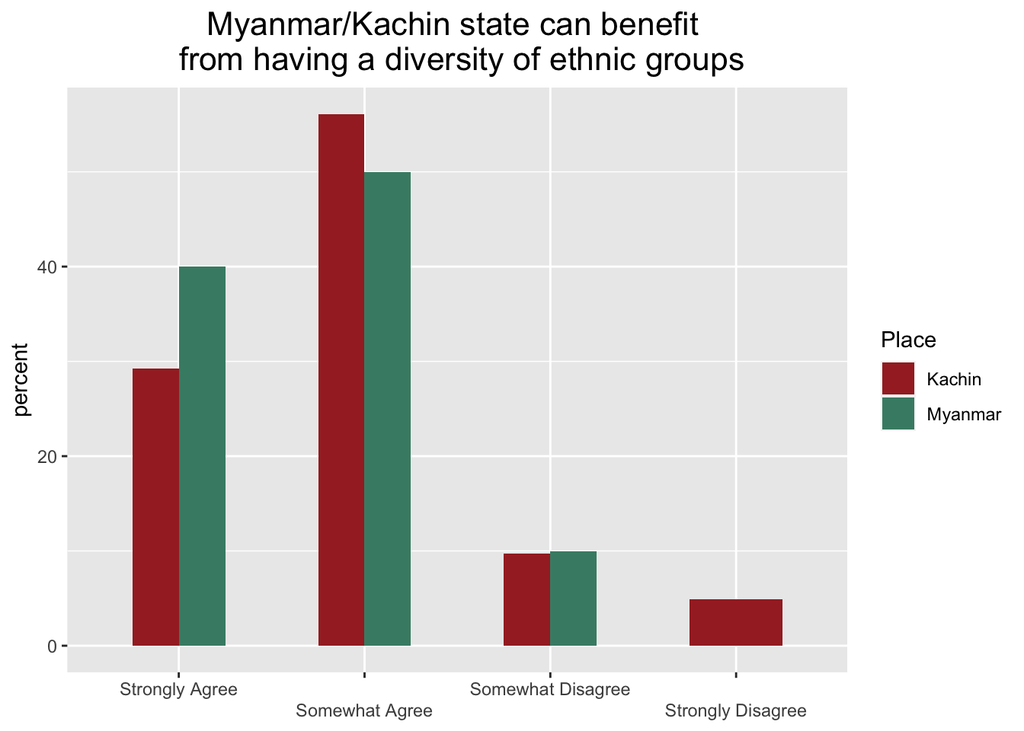

## 2.3 Trust

I ask respondents how much they would trust someone from different identity categories]. In particular, I am interested in how respondents would respond when it comes to ethnicity, and how this compares to those from the same village/ward as the respondent.

87.5% of respondents are likely to trust a co-ethnic compared to 65% who are likely to trust a non-coethnic. This is in comparison to 80% of respondents who are likely to trust someone from the same village/ward.

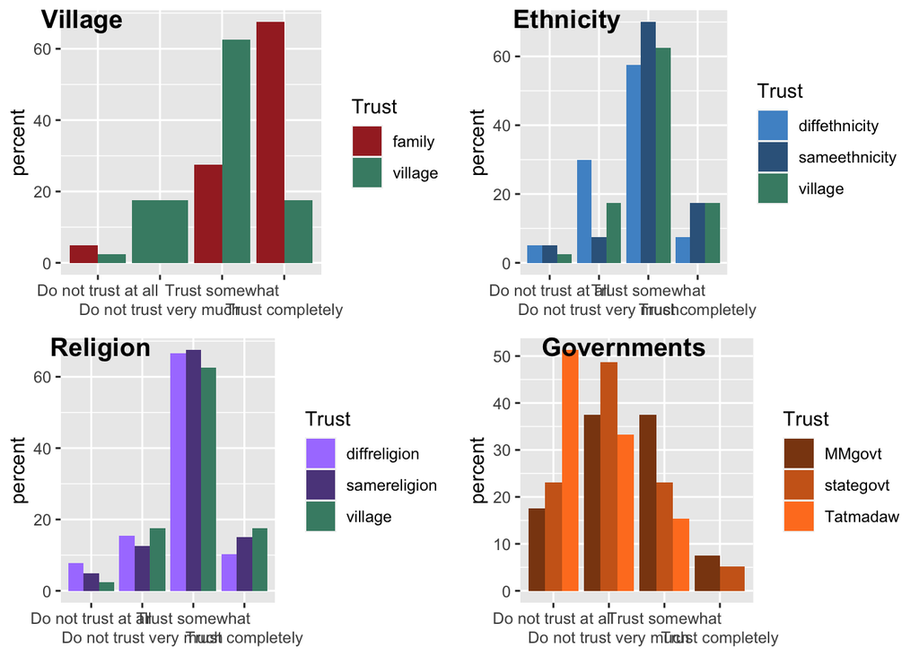

From this section onwards, I filtered the dataset to only include respondents who are Kachin (excluding those who are of mixed heritage, i.e. Kachin and another “national race”).

I use a different question adapted from WVS that aims to break down trust according to ethnic group. Even if individuals are less likely to trust a non-coethnic compared to a coethnic, is there variation among non-coethnics?

Here, we can see very clearly that a much higher proportion of my respondents express more negative sentiments towards Bamar people compared to the other ethnicities. 75.9% of Kachin respondents expressed negative seniments towards Bamar people, compared to 37.9% for Shan people, nearly doubel the amount.

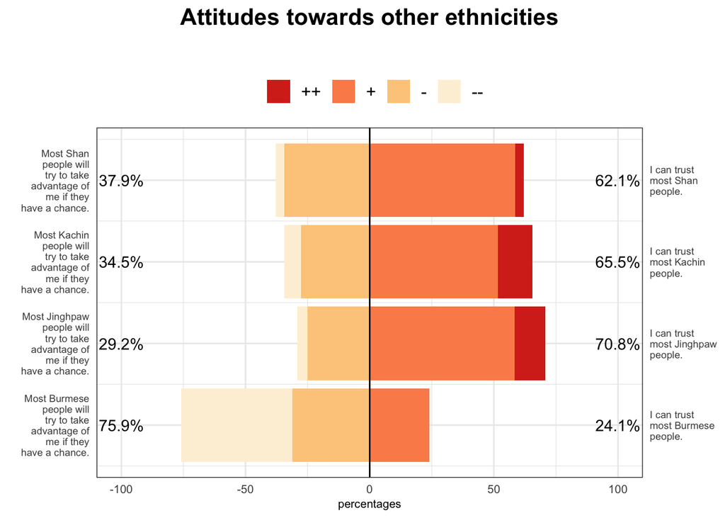

I look at beliefs concerning whether people of different ethnicities can live together. A higher proportion of negative sentiments were expressed towards Bamars - 60% of Kachin respondents believed Kachin and Bamar people cannot live together compared to approx. 20% for Kachin and Shan people.

With a larger sample size, it would again be interesting to break down these attitudes by Jinghpaw and non-Jinghpaw speakers.

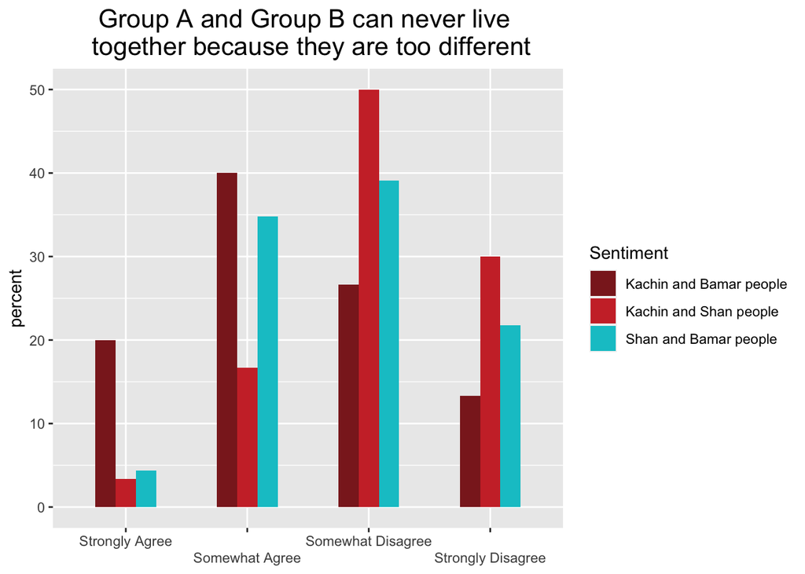

I also look at degree of acceptance when it comes to intermarriage. About 68% of respondents cannot accept it if their child marries a Burmese. This is similar to the proportion of respondents who cannot accept their child marrying another ethnic minority from a different faith. Given the centrality of faith to many people in the Kachin community, the latter is not surprising.

What we see consistently, however, is a strong animosity towards Bamar people.

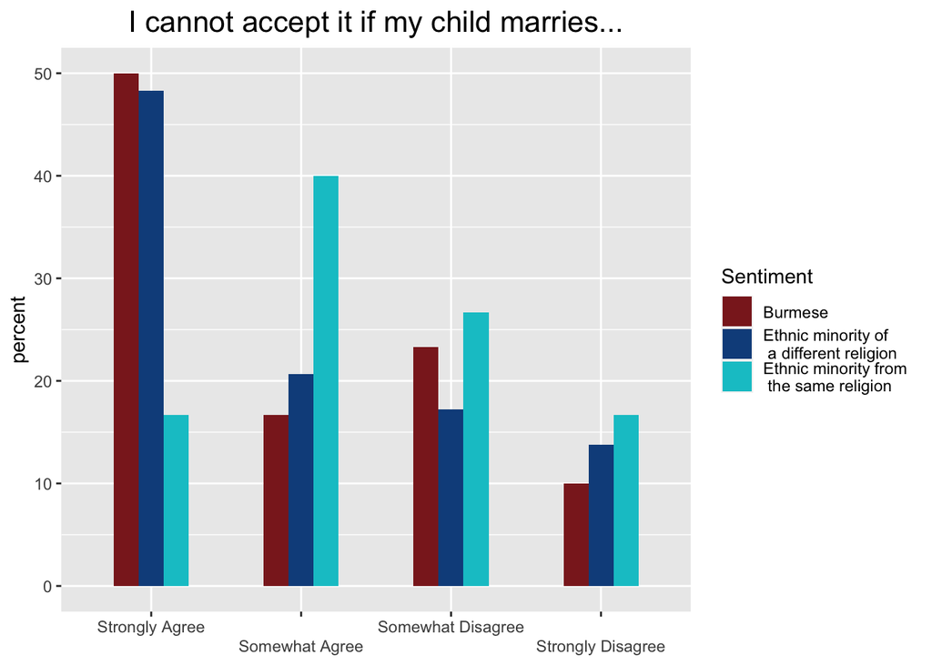

I now look at my conjoint experiment.

The Average Marginal Component Effect (AMCE) tells me the marginal effect of attribute averaged over the joint distribution of the remaining attributes. The model constructed here takes into account the restrictions I introduced to ensure that the profiles shown to respondents are feasible, thereby not compromising the validity of the experiment.

We can see that the AMCE coefficients are statistically significant for Shan ethnicity (although not for Kachin, with the reference category being Bamar), Hometown and Religion.

As a reminder, H1 for my Paper 2 is: *The AMCE for local identity would be higher than ethnicity.*

Initially when I was planning the survey, I had wanted to find a way to construct a single attribute for local identity, which would involve combining hometown and language(s) understood. I am not sure if this is possible. For this pre-test, however, I have simply used hometown as a proxy for local identity.

For my eventual data, I also hope to see if the results I get from the conjoint experiment reflects the answers from the direct questions asked previously. This would allow me to evaluate the reliability of these commonly used survey questions.

```
## ------------------------------------------
## Average Marginal Component Effects (AMCE):
## ------------------------------------------
##   Attribute                       Level  Estimate Std. Err  z value   Pr(>|z|)
##        cEdu                   Secondary  0.033065 0.084797  0.38994 0.69658430
##  cEthnicity                      Kachin  0.353521 0.180964  1.95355 0.05075498
##  cEthnicity                        Shan  0.436541 0.122085  3.57570 0.00034929 ***
##   cHometown                    Waingmaw  0.404567 0.114647  3.52881 0.00041744 ***
##   cLanguage          Jinghpaw and Bamar  0.234800 0.207868  1.12956 0.25866048
##   cLanguage Jinghpaw and Shan and Bamar -0.075602 0.122165 -0.61885 0.53601448
##   cLanguage              Shan and Bamar  0.016002 0.153355  0.10434 0.91689594
##        cOcc                      Vendor -0.067510 0.080640 -0.83718 0.40248866
##   cReligion                   Christian  0.250727 0.092943  2.69764 0.00698339  **
## ---
## Number of Obs. = 152
## ---
## Number of Respondents = 39
## ---
## Signif. codes: 0 '***' 0.001 '**' 0.01 '*' 0.05
##
## --------------------
## AMCE Baseline Levels:
## --------------------
##   Attribute    Level
##        cEdu  Primary
##  cEthnicity    Bamar
##   cHometown    Hlegu
##   cLanguage    Bamar
##        cOcc   Farmer
##   cReligion Buddhist
```

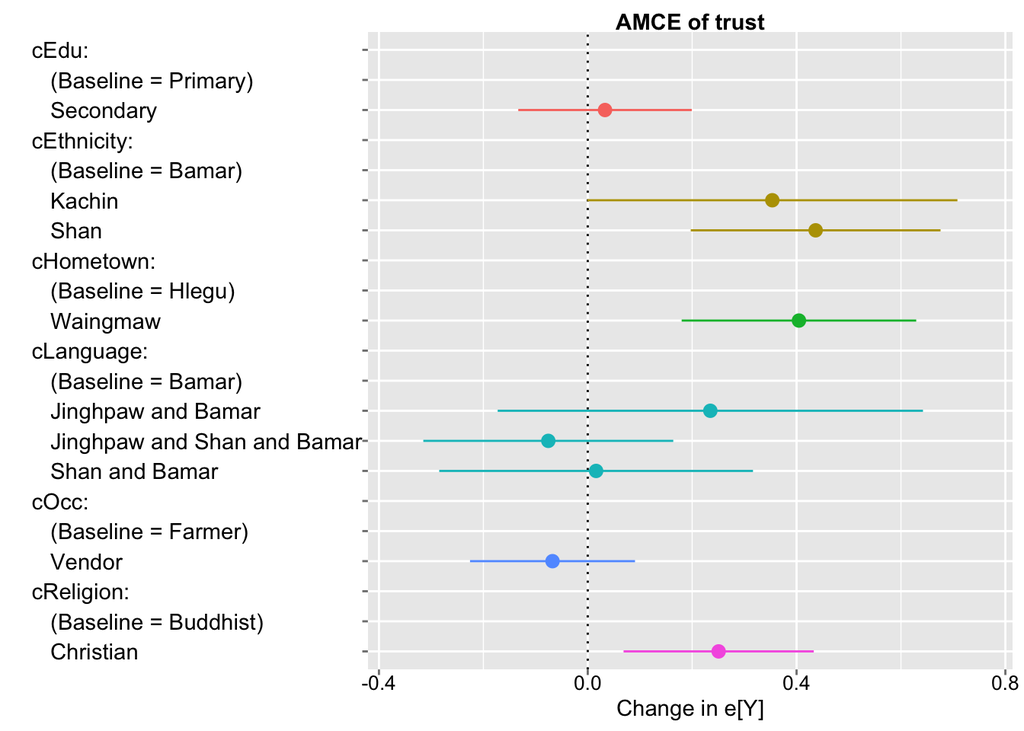

I interact the attributes with the respondents’ characteristics, in particular, focusing on those who are Jinghpaw. When an individual is Jinghpaw, Shan ethniity, hometown and religion are statistically significant. When an individual is non-Jinghpaw, none of the attributes are statistically significant.

*H6: Respondents who identify as Jinghpaw would be more likely to rely on ethnicity as a cognitive shortcut.*

```
## ------------------------------------------
## Average Marginal Component Effects (AMCE):
## ------------------------------------------
##   Attribute                       Level  Estimate Std. Err  z value   Pr(>|z|)
##        cEdu                   Secondary  0.033065 0.084797  0.38994 0.69658430
##  cEthnicity                      Kachin  0.353521 0.180964  1.95355 0.05075498
##  cEthnicity                        Shan  0.436541 0.122085  3.57570 0.00034929 ***
##   cHometown                    Waingmaw  0.404567 0.114647  3.52881 0.00041744 ***
##   cLanguage          Jinghpaw and Bamar  0.234800 0.207868  1.12956 0.25866048
##   cLanguage Jinghpaw and Shan and Bamar -0.075602 0.122165 -0.61885 0.53601448
##   cLanguage              Shan and Bamar  0.016002 0.153355  0.10434 0.91689594
##        cOcc                      Vendor -0.067510 0.080640 -0.83718 0.40248866
##   cReligion                   Christian  0.250727 0.092943  2.69764 0.00698339  **
## ---
## Number of Obs. = 152
## ---
## Number of Respondents = 39
## ---
## ------------------------------------------------------------
## Conditional AMCE's (Jinghpaw = 0):
## ------------------------------------------------------------
##   Attribute                       Level  Estimate Std. Err  z value Pr(>|z|)
##  cEthnicity                      Kachin  0.451662  0.23912  1.88883 0.058914
##  cEthnicity                        Shan  0.546720  0.28172  1.94062 0.052304
##   cHometown                    Waingmaw  0.405443  0.21028  1.92810 0.053843
##   cReligion                   Christian  0.045666  0.15012  0.30419 0.760985
##        cOcc                      Vendor -0.098516  0.12887 -0.76448 0.444581
##        cEdu                   Secondary  0.014654  0.13025  0.11251 0.910420
##   cLanguage          Jinghpaw and Bamar  0.216657  0.31730  0.68282 0.494720
##   cLanguage Jinghpaw and Shan and Bamar -0.396349  0.20608 -1.92326 0.054447
##   cLanguage              Shan and Bamar -0.072605  0.17191 -0.42235 0.672771
## ---
## Number of Obs. = 152
## Number of Respondents = 39
## ---
## Signif. codes: 0 '***' 0.001 '**' 0.01 '*' 0.05
##
## ------------------------------------------------------------
## Conditional AMCE's (Jinghpaw = 1):
## ------------------------------------------------------------
```

[output cut: 13 more lines]

```
## ---
## Signif. codes: 0 '***' 0.001 '**' 0.01 '*' 0.05
##
## Signif. codes: 0 '***' 0.001 '**' 0.01 '*' 0.05
##
## --------------------
## AMCE Baseline Levels:
## --------------------
##   Attribute    Level
##        cEdu  Primary
##  cEthnicity    Bamar
##   cHometown    Hlegu
##   cLanguage    Bamar
##        cOcc   Farmer
##   cReligion Buddhist
```

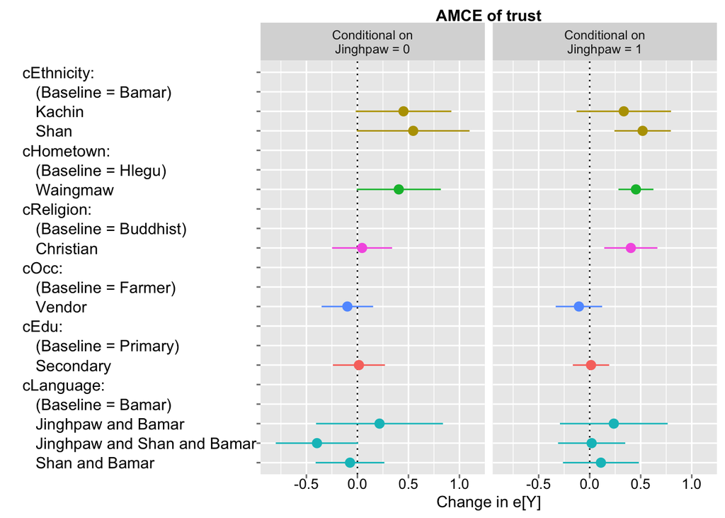

I also include an interaction for whether the profile provided is of the same ethnicity as the respondent. When the profile provided is of a non-coethnic, religion and language spoken matters. When the profile provided is of a coethnic, hometown matters.

*H3: Local identity would have a greater effect on evaluating a non co-ethnic’s profile compared to a co-ethnic’s profile.*

```
## ------------------------------------------
## Average Marginal Component Effects (AMCE):
## ------------------------------------------
##   Attribute                       Level  Estimate Std. Err  z value   Pr(>|z|)
##        cEdu                   Secondary  0.020413 0.078384  0.26043 0.79453372
##  cEthnicity                       Bamar -0.456322 0.130420 -3.49886 0.00046725 ***
##  cEthnicity                        Shan -0.104007 0.128848 -0.80720 0.41954996
##   cHometown                    Waingmaw  0.293941 0.106744  2.75371 0.00589238  **
##   cLanguage          Jinghpaw and Bamar -0.066940 0.120811 -0.55409 0.57951672
##   cLanguage Jinghpaw and Shan and Bamar -0.022527 0.150769 -0.14941 0.88122868
##   cLanguage              Shan and Bamar  0.057277 0.167803  0.34133 0.73285354
##        cOcc                      Vendor -0.150798 0.094070 -1.60304 0.10892592
##   cReligion                   Christian  0.307557 0.102290  3.00671 0.00264093  **
## ---
## Number of Obs. = 116
## ---
## Number of Respondents = 30
## ---
## ------------------------------------------------------------
## Conditional AMCE's (coethnic = 0):
## ------------------------------------------------------------
##   Attribute                       Level   Estimate Std. Err  z value  Pr(>|z|)
##  cEthnicity                       Bamar -0.4446748 0.241310 -1.84275 0.0653653
##  cEthnicity                        Shan  0.1984604 0.252012  0.78751 0.4309860
##   cHometown                    Waingmaw  0.0899277 0.158911  0.56590 0.5714620
##   cReligion                   Christian  0.2843835 0.094772  3.00071 0.0026935 **
##        cOcc                      Vendor -0.2042697 0.107706 -1.89655 0.0578873
##        cEdu                   Secondary -0.0070588 0.106068 -0.06655 0.9469403
##   cLanguage          Jinghpaw and Bamar  0.4754044 0.204054  2.32979 0.0198171  *
##   cLanguage Jinghpaw and Shan and Bamar  0.2692326 0.237008  1.13596 0.2559719
##   cLanguage              Shan and Bamar  0.0691413 0.179893  0.38435 0.7007220
## ---
## Number of Obs. = 116
## Number of Respondents = 30
## ---
## Signif. codes: 0 '***' 0.001 '**' 0.01 '*' 0.05
##
## ------------------------------------------------------------
## Conditional AMCE's (coethnic = 1):
## ------------------------------------------------------------
```

[output cut: 13 more lines]

```
## ---
## Signif. codes: 0 '***' 0.001 '**' 0.01 '*' 0.05
##
## Signif. codes: 0 '***' 0.001 '**' 0.01 '*' 0.05
##
## --------------------
## AMCE Baseline Levels:
## --------------------
##   Attribute    Level
##        cEdu  Primary
##  cEthnicity   Kachin
##   cHometown    Hlegu
##   cLanguage    Bamar
##        cOcc   Farmer
##   cReligion Buddhist
```

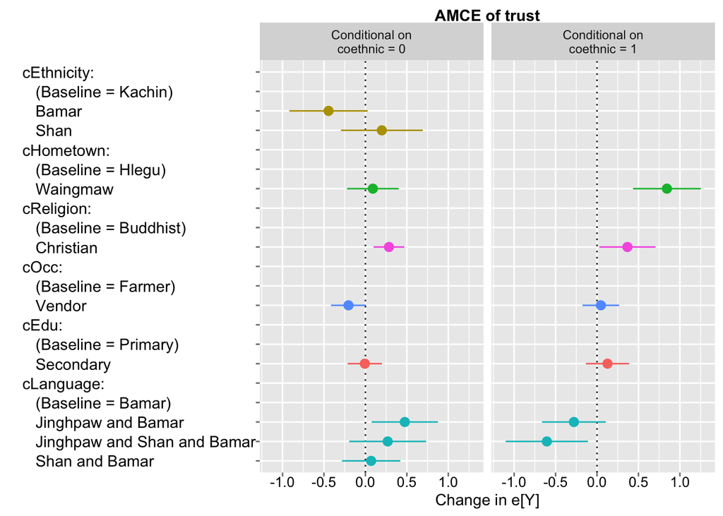

Finally, I conduct an interaction based on levels of ethnic identification. Here, we see that for those who do not feel the closest to the Kachin ethnic category do not distinguish between ethnicities, whereas those who feel closest do.

*H5: Respondents who have higher levels of ethnic identification would be more likely to use ethnicity as a cognitive shortcut.*

```
## ------------------------------------------
## Average Marginal Component Effects (AMCE):
## ------------------------------------------
##   Attribute                       Level  Estimate Std. Err  z value  Pr(>|z|)
##        cEdu                   Secondary  0.023676  0.10952  0.21617 0.8288514
##  cEthnicity                       Bamar -0.425080  0.17003 -2.50002 0.0124186  *
##  cEthnicity                        Shan -0.192634  0.19070 -1.01012 0.3124355
##   cHometown                    Waingmaw  0.344276  0.12446  2.76622 0.0056710 **
##   cLanguage          Jinghpaw and Bamar -0.042099  0.13624 -0.30901 0.7573150
##   cLanguage Jinghpaw and Shan and Bamar -0.055550  0.18656 -0.29777 0.7658822
##   cLanguage              Shan and Bamar -0.110629  0.23551 -0.46974 0.6385375
##        cOcc                      Vendor -0.131775  0.12296 -1.07166 0.2838742
##   cReligion                   Christian  0.389523  0.13288  2.93138 0.0033746 **
## ---
## Number of Obs. = 86
## ---
## Number of Respondents = 22
## ---
## ------------------------------------------------------------
## Conditional AMCE's (closestKachin = 0):
## ------------------------------------------------------------
##   Attribute                       Level  Estimate Std. Err  z value Pr(>|z|)
##  cEthnicity                       Bamar -0.305940  0.23126 -1.32294 0.185857
##  cEthnicity                        Shan -0.199766  0.19152 -1.04304 0.296931
##   cHometown                    Waingmaw  0.345502  0.16339  2.11462 0.034462 *
##   cReligion                   Christian  0.416347  0.16505  2.52258 0.011650 *
##        cOcc                      Vendor  0.017356  0.15266  0.11369 0.909483
##        cEdu                   Secondary -0.022652  0.14416 -0.15713 0.875142
##   cLanguage          Jinghpaw and Bamar  0.230597  0.24334  0.94762 0.343320
##   cLanguage Jinghpaw and Shan and Bamar -0.187103  0.26413 -0.70838 0.478707
##   cLanguage              Shan and Bamar -0.043059  0.35771 -0.12037 0.904187
## ---
## Number of Obs. = 86
## Number of Respondents = 22
## ---
## Signif. codes: 0 '***' 0.001 '**' 0.01 '*' 0.05
##
## ------------------------------------------------------------
## Conditional AMCE's (closestKachin = 1):
## ------------------------------------------------------------
```

[output cut: 13 more lines]

```
## ---
## Signif. codes: 0 '***' 0.001 '**' 0.01 '*' 0.05
##
## Signif. codes: 0 '***' 0.001 '**' 0.01 '*' 0.05
##
## --------------------
## AMCE Baseline Levels:
## --------------------
##   Attribute    Level
##        cEdu  Primary
##  cEthnicity   Kachin
##   cHometown    Hlegu
##   cLanguage    Bamar
##        cOcc   Farmer
##   cReligion Buddhist
```

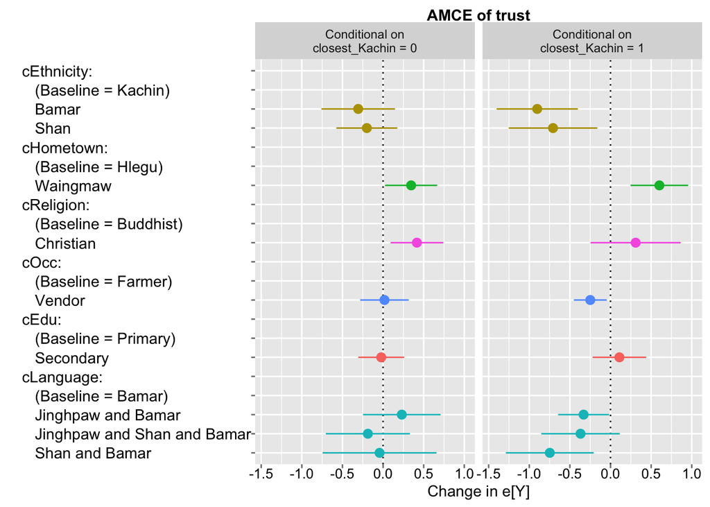

## 2.4 Perceptions of and Experiences with Discrimination

I look at attitudes towards how Kachin state should be governed. Just over 70% of Kachin respondents agreed that Kachin state should be governed only by Kachin people. This is in contrast to the approx. 65% of respondents who disagreed that Kachin state should be governed by Kachin and Shan people.

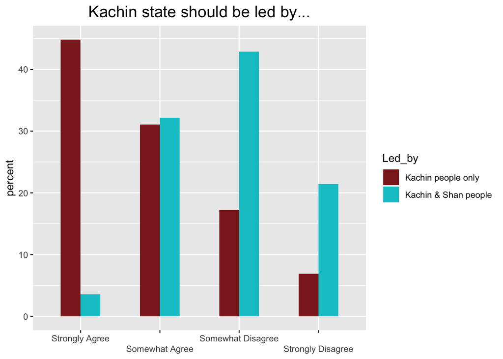

I ask respondents to react to the statement “Burmese people look down on ethnic minorities”. The results relate to earlier results, with approx. 83% of respondents agreeing with the statement.

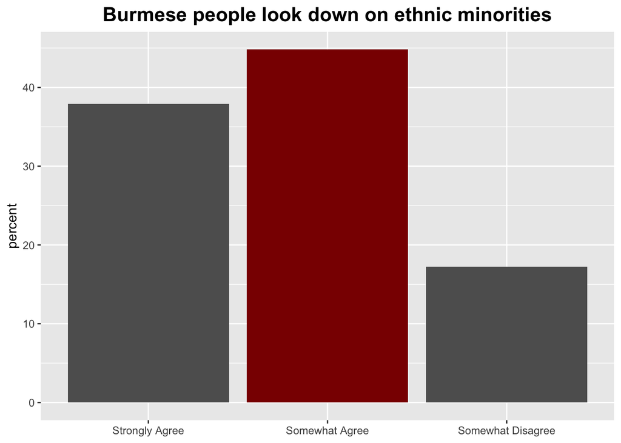

Here, we see the perceptions of general discrimination in both Myanmar and Kachin state.

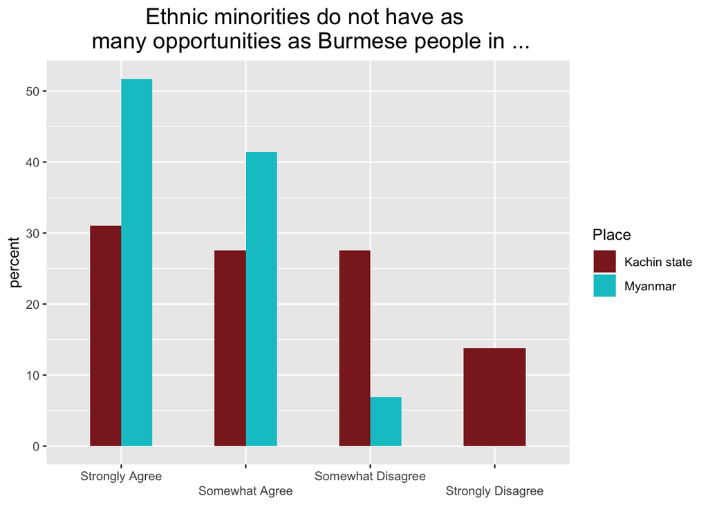

Finally, we look at personal experiences of discrimination. I differentiate between the Burmese government and Bamar people.

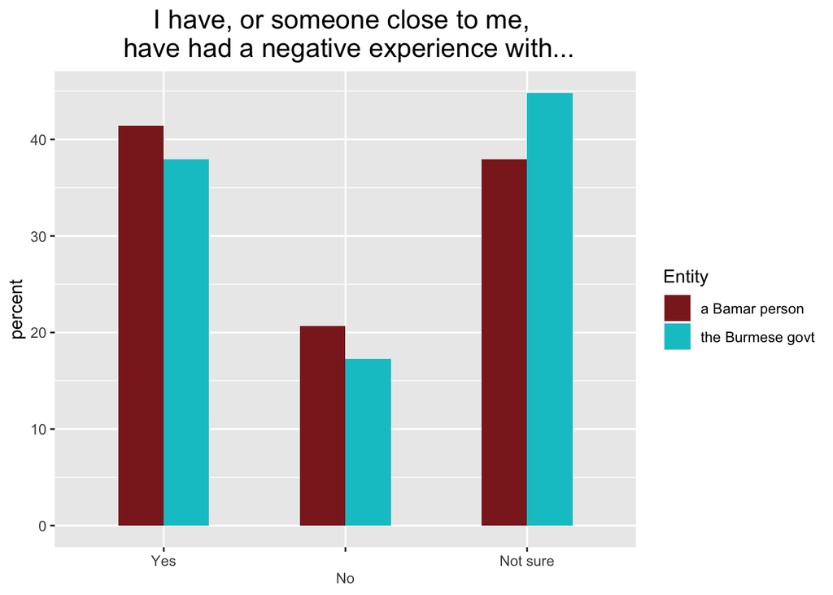